# SOC301B — R Cheatsheet (2): Statistics

What we compute, why, and how to read it

*This is part 2 of the cheatsheet: **statistics**. Part 1 covers **programming** (loading data, transforming it, making tables and plots). Here, we assume you know how to do all of that, and we focus on what the numbers mean.*

*As in part 1, all examples use the Titanic dataset. Put `titanic.csv` in the same folder as this .qmd file. The chunk below loads it, and creates the readable labels we use in plots.*

```r
library(tidyverse)
library(knitr)

data = read.csv("titanic.csv")

data = data %>%
  mutate(Survived_label = factor(Survived,
                                 levels = c(0, 1),
                                 labels = c("Did not survive", "Survived")))
```

# 1. Descriptive vs inferential statistics

Before computing anything, you need to be clear about *what kind of statement* you want to make. There are two kinds, and confusing them is one of the most common mistakes in data analysis.

## 1.1 Descriptive statistics: what we see in the sample

Descriptive statistics describe **your sample**, and only your sample. Counts, percentages, means, medians, tables, plots: everything we did in part 1.

For example, what was the survival rate of women and men?

```r
data %>%
  group_by(Sex) %>%
  summarise(survival_rate = mean(Survived) * 100,
            n = n())
```

| Sex | survival_rate | n |
| --- | --- | --- |
| female | 74.20382 | 314 |
| male | 18.89081 | 577 |

“In our dataset, 74% of women survived, against 19% of men.” This is simply a fact about the 891 passengers in the data. There is no uncertainty about it: we counted.

## 1.2 Inferential statistics: what we can say beyond the sample

Most of the time, we don’t care about the sample in itself: we care about the **larger population** we did not fully observe. And our dataset is in fact a sample: there were about 2,200 people on board the Titanic, and we only have 891 of them.

So the real question is: “Did women have a higher chance of surviving than men, *among everyone on board*?” To answer it, we use our sample to make an *inference* about the population. And since we only see part of the population, there is always uncertainty: **another sample would have given slightly different numbers.**

You can see this uncertainty with your own eyes. Imagine we only had data on 100 passengers, drawn at random. The code below draws three different random samples of 100 passengers, and computes the survival rate by sex in each one:

```r
set.seed(1) # makes the random draws reproducible: you'll get the same samples as me

for (i in 1:3) {
  data %>%
    slice_sample(n = 100) %>%  # draw 100 passengers at random
    group_by(Sex) %>%
    summarise(survival_rate = mean(Survived) * 100) %>%
    print()
}
```

```
# A tibble: 2 × 2
  Sex    survival_rate
  <chr>          <dbl>
1 female          80
2 male            16.7
# A tibble: 2 × 2
  Sex    survival_rate
  <chr>          <dbl>
1 female          74.2
2 male            13.0
# A tibble: 2 × 2
  Sex    survival_rate
  <chr>          <dbl>
1 female          75
2 male            17.9
```

Each sample tells roughly the same story (women survived more), but the exact numbers move around from one sample to another. That’s sampling luck. Inferential statistics are the tools that **measure this uncertainty**: standard errors, confidence intervals, and p-values. They answer the question: “given how much my numbers could move around by luck, can I trust what I see?”

## 1.3 Summary

|  | Descriptive | Inferential |
| --- | --- | --- |
| Talks about | the sample | the population |
| Question | “What do we see in the data?” | “What can we conclude beyond the data?” |
| Tools | `count()`, `mean()`, `summarise()`, `kable()`, plots | standard errors, confidence intervals, p-values, `lm()`, `cor.test()` |
| Uncertainty | none | always |

*NB: The same analysis can contain both. In a regression, the slope is descriptive: it’s the best line through* your* dots. Its standard error and p-value are inferential: they tell you whether this slope would likely hold beyond your sample.*

# 2. Linear regression

## 2.1 What a linear regression really is

A linear regression is not a property of the data: it’s a **decision** we make as analysts. The decision to summarize the relationship between two variables with a straight line, using the equation you know from middle school:

$$y = ax + b$$

In words: the value of y (say, the fare paid) is given by the value of x (say, age) multiplied by a coefficient a, plus another coefficient b.

- **a** is the **slope**: how much y changes when x increases by one unit. Positive → the line goes up. Negative → the line goes down. Zero → the line is flat: x tells us nothing about y.
- **b** is the **intercept** (“l’ordonnée à l’origine”): the value of y when x = 0, i.e. where the line crosses the y-axis.

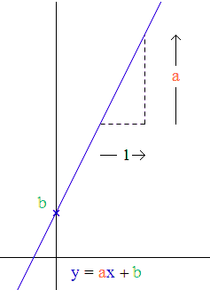

In statistics, we write the exact same thing with other symbols: $y = \beta_0 + \beta_1 \times x$. Here $\beta_0$ is the intercept and $\beta_1$ the slope.

That’s the whole mathematical content. Everything else in a regression output (standard errors, p-values, R²) is extra information about this line: how well it fits the data, and what we can say beyond our sample. But the line itself is the heart of it. Keep that image in your head.

## 2.2 Start with a plot

Let’s take a question: **did older passengers pay more for their tickets?** Before running any model, always look at the data. Both variables are continuous, so we use a scatterplot, with the regression line on top:

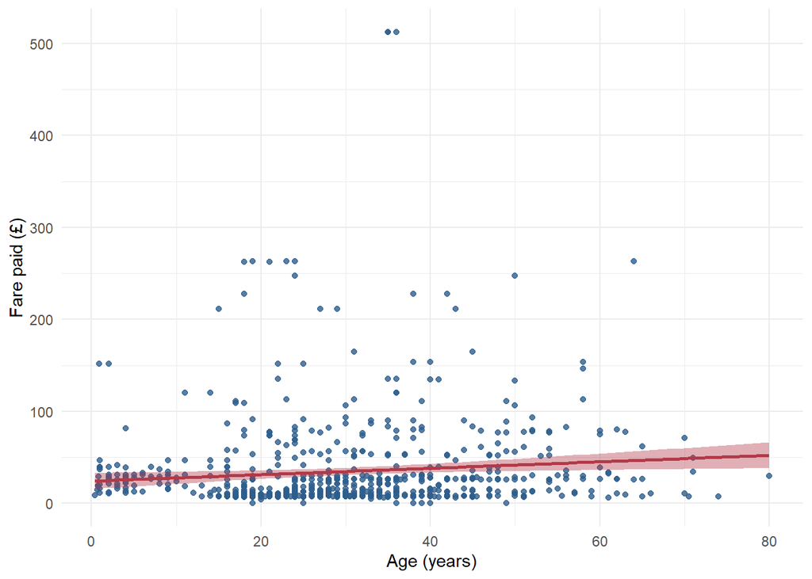

```r
ggplot(data, aes(x = Age, y = Fare)) +
  geom_point(alpha = 0.8, color = "#2E5E8C") +
  geom_smooth(method = "lm", color = "#B23A48", fill = "#B23A48") +
  labs(x = "Age (years)", y = "Fare paid (£)") +
  theme_minimal()
```

The red line is a linear regression: the straight line that best summarizes the relationship between age and fare. It goes slightly up, and the dots are very scattered around it.

But “the line that best summarizes” is vague. Among all the straight lines we could draw through this cloud, how does R choose this one?

## 2.3 How the line is chosen: ordinary least squares

**There are infinitely many possible lines.** Through any cloud of dots, you can draw a steep line, a flat line, a line going down, a line starting high or low… Each line is defined by one intercept and one slope. The question is: which one fits the data best?

To see this clearly, let’s take a small sample of 100 passengers and only keep fares below 100 £ here, so the plot stays readable.

```r
set.seed(3) # makes the random draw reproducible
small = data %>%
  filter(!is.na(Age), Fare < 100) %>%
  slice_sample(n = 100)
```

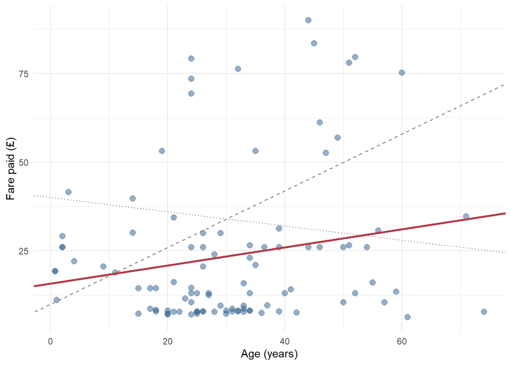

```r
m_small = lm(Fare ~ Age, data = small)

ggplot(data = small, aes(x = Age, y = Fare)) +
  geom_point(alpha = 0.5, size = 2.5, color = "#2E5E8C") +
  geom_abline(intercept = 10, slope = 0.8, color = "grey50", linetype = "dashed") +
  geom_abline(intercept = 40, slope = -0.2, color = "grey50", linetype = "dotted") +
  geom_abline(intercept = coef(m_small)[1], slope = coef(m_small)[2],
              color = "#B23A48", linewidth = 1) +
  labs(x = "Age (years)", y = "Fare paid (£)") +
  theme_minimal()
```

- **Line A** (dashed): intercept 10, slope 0.8. It goes up quite steeply.
- **Line B** (dotted): intercept 40, slope −0.2. It goes slightly down.
- **Line C** (red): the line chosen by R when running a linear regression.

All three are “possible”. To decide which is best, we need a way to measure how far a line is from the data. What makes Line C the best line to summarize the data?

**Step 1: the residuals.** For each passenger, the line *predicts* a fare. The distance between the passenger’s *actual* fare and the fare *predicted* by the line is called the **residual**: it’s the error the line makes for this passenger. On the plot below, each residual is a vertical grey segment between a dot and the red line:

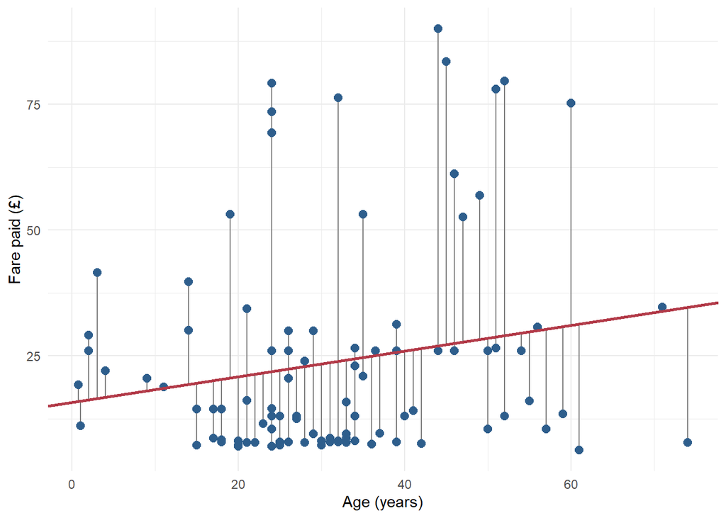

```r
small = small %>%
  mutate(predicted = predict(m_small))

ggplot(small, aes(x = Age, y = Fare)) +
  geom_segment(aes(xend = Age, yend = predicted), color = "grey50") +
  geom_point(size = 2.5, color = "#2E5E8C") +
  geom_abline(intercept = coef(m_small)[1], slope = coef(m_small)[2],
              color = "#B23A48", linewidth = 1) +
  labs(x = "Age (years)", y = "Fare paid (£)") +
  theme_minimal()
```

A dot above the line has a positive residual (the passenger paid more than predicted); a dot below has a negative residual (they paid less than predicted).

**Step 2: square the residuals and add them up.** A good line should make small errors overall. But we can’t just add up the residuals: positive and negative ones would cancel each other out, and a terrible line could get a total of zero. So we **square** each residual first (a square is always positive), and then add them up. This gives the **sum of squared residuals**: one single number that measures how badly a line fits the data. The smaller, the better.

Let’s compute it for our three lines:

```r
small %>%
  summarise(line_A = sum((Fare - (10 + 0.8 * Age))^2), #because we defined this line as intercept = 10, slope = 0.8
            line_B = sum((Fare - (40 - 0.2 * Age))^2), #because we defined this line as intercept = 40, slope = -0.2
            line_C = sum(residuals(m_small)^2)) #using the residuals() function to compute residuals
```

| line_A | line_B | line_C |
| --- | --- | --- |
| 61894.49 | 58167.32 | 42657.6 |

Line C makes much smaller errors than the two others.

**Step 3: find the line with the smallest possible sum.** We could try lines one by one forever. Instead, there is a mathematical formula that directly finds, among *all* possible lines, the one with the smallest sum of squared residuals. This method is called **ordinary least squares** (OLS): “least squares” because it minimizes the sum of the squares. That’s what `lm()` does, and that’s how it found line C.

So when we say “the line that best fits the data”, we mean something very precise: **the line that minimizes the sum of squared residuals.** No other straight line makes smaller errors, in this sense.

*NB: “Best” doesn’t mean “good”. OLS always finds the best straight line, even when the data doesn’t look like a straight line at all, or when the line fits terribly. It’s your job to check that a straight line makes sense (see section 2.8).*

## 2.4 Fit a model: `lm()`

Back to the full dataset. The function is `lm()`, for “linear model”. The syntax is `lm(outcome ~ predictor, data = ...)`:

- the **outcome** (y) is the variable you want to explain: here, the fare;
- the **predictor** (x) is the variable you use to explain it: here, age;
- read the `~` as “is predicted by”: “fare is predicted by age”.

We store the model in an object (here `m1`), and then display its results with `summary()`:

```r
m1 = lm(Fare ~ Age, data = data)
summary(m1)
```

```
Call:
lm(formula = Fare ~ Age, data = data)

Residuals:
   Min     1Q Median     3Q    Max
-42.42 -24.49 -17.60   2.33 475.78

Coefficients:
            Estimate Std. Error t value Pr(>|t|)
(Intercept)  24.3009     4.4922   5.410 8.64e-08 ***
Age           0.3500     0.1359   2.575   0.0102 *
---
Signif. codes:  0 '***' 0.001 '**' 0.01 '*' 0.05 '.' 0.1 ' ' 1

Residual standard error: 52.71 on 712 degrees of freedom
  (177 observations effacées parce que manquantes)
Multiple R-squared:  0.009229,  Adjusted R-squared:  0.007837
F-statistic: 6.632 on 1 and 712 DF,  p-value: 0.01022
```

The output looks scary, but you only need three things:

1. the **`Coefficients` table**: one row for the intercept, one row for the slope;
2. the line **`Multiple R-squared`**, near the bottom;
3. the note **`(177 observations deleted due to missingness)`**: R automatically removed the 177 passengers whose age is unknown. So the model is fitted on 891 − 177 = 714 passengers. Always check this line: you need to know how many observations your results are based on.

In the `Coefficients` table, each row has four columns: `Estimate`, `Std. Error`, `t value`, and `Pr(>|t|)` (the p-value). Let’s go through them one by one.

## 2.5 Reading the output

For each element of the output, I give you: what it is, **how to formulate it** in a report, and **the traps to avoid**.

*Learn the formulations: they are what I expect in your reports.*

### 2.5.1. Descriptive results

First and foremost, there are descriptive aspects of the model: these are aspects that tell you about how much the linear model fits the sample, but tell you nothing about how these results can be generalized to the whole population.

#### **The intercept**

**What it is:** the predicted value of y when x = 0. It’s where the line crosses the y-axis.

**How to say it:**

> ✅ “For a passenger aged 0, the model predicts a fare of 24.3 £.”

**Traps:**

- Nobody in the data is exactly 0 years old. When x = 0 is impossible or outside your data (age 0, height 0, income 0…), the intercept is just a mathematical property of the line, not a meaningful information for your research question. Report it, but don’t build a conclusion on it.
- The p-value of the intercept tests whether the intercept is different from 0. In most cases, this is not an interesting question, in which case you can ignore it.

#### The slope

**What it is:** how much the predicted value of y changes when x increases by one unit. It’s the answer to your research question.

**How to say it:**

> ✅ “On average, each additional year of age is associated with a fare 0.35 £ higher.”

Three things must appear in your formulation:

1. **the units** of both variables (“each additional *year*”, “0.35 *£*”);
2. **“on average”**: the line describes the general trend, not each passenger;
3. **“is associated with”**: not “causes”, not “leads to”, not “increases”.

**Traps:**

> ❌ “Getting older makes people pay more.” / “Age increases the fare.”

A regression shows an **association**, not a cause. Maybe older passengers were richer, maybe they traveled in better classes… The model can’t tell the difference.

> ❌ “Each passenger paid 0.35 £ more than passengers a year younger.”

No: the dots are scattered all around the line. Some older passengers paid much less than younger ones. The slope describes the average trend.

> ❌ “The slope is 0.35, so the relationship is weak.” (without additional explanation)

The size of the slope depends on the **units**. If fare were in pence (“centimes”) instead of pounds, the slope would be 35 instead of 0.35, for exactly the same relationship. It is your human interpretation that determines whether the relationship is considered strong or weak. This is why it’s crucial to always report the units of your predictor and outcome.

**NoteInterpreting effect size**

It’s always essential to report, and comment on the **effect size**.

- Sometimes, it’s intuitive whether an effect size is strong or weak. For instance, imagine that your regression finds that: “Each additional year smoking one pack of cigarettes a day reduces life expectancy by 2 years”. You can intuitively argue that this is a lot.
- Other times, the effect size is not clear in itself. For instance: “each additional year of age is associated with a fare 0.35 £ higher”. Is it a small or big effect? To make the effect more palatable, it can be a good idea to compare extreme ends: for instance, the predicted difference in paid fare between 20yo and 80yo individuals. Here, for instance, this model predicts that a 20yo will pay 31.4 pounds fare (I just applied the model results and calculated: *24.4+20*0.35 = 31.4*). And for a 80yo: *24.4+80*0.35 = 52.4 pounds*. In sum, our model expects an 80yo person to pay 1.6 times more for their ticket than a 20 year old. There is still some subjective dimension in saying whether this is a lot or not, but at least now the magnitude of the effect is more intuitive!

### R²

**What it is:** R² tells you **what share of these differences in fare the model accounts for**. It goes from 0 (the line explains nothing: knowing x doesn’t help predicting y at all) to 1 (the line explains everything: all dots are exactly on the line). Visually, R² captures how much the dots are scattered around the line

Here, R² = 0.009, i.e. 0.9%.

**How to say it:**

> ✅ “Age explains 0.9% of the variation in fare between passengers.”

**Traps:**

> ❌ “R² is low, so there is no relationship.”

There *is* a relationship (the slope is different from 0). R² tells you that this relationship doesn’t explain a lot of the variance, meaning that age matters, but it’s only a tiny part of the story. Fare depends on many things (class, cabin, family size…).

> ❌ “R² is low, so the model is wrong / useless.”

In the social sciences, low R² are very common: human behavior depends on many factors, and one variable rarely explains a large part of it. A model with a low R² can still answer your question perfectly well. However, it can put your result in perspective and remind you that you don’t explain the full picture.

### 2.5.2. Inferencial statistics results

These values tell you nothing about how well the line fits the data in your sample. But it tells you to what extent these results can be generalized to the whole population.

### The p-value

**What it is:** the p-value answers one specific question, always the same:

*Suppose that in reality (in the population), there is **no relationship at all** between x and y: the true slope is exactly zero. In that case, what would be the probability of finding, just by the luck of which observations ended up in our sample, a slope at least as far from zero as the one we found?*

If this probability is very small, it means our result would be very surprising in a world with no relationship. So we conclude that this world (true slope = 0) is probably not the one we live in.

Here, p = 0.01.

**How to say it:**

> ✅ “If there were no relationship between age and fare in the population, there would be only a 1% chance of finding a slope as far from zero as 0.35 in a sample like ours. Thus, based on a threshold of significance of 0.05, we can reject the hypothesis that the true slope is zero.”

By convention, we call a result **statistically significant** when p < 0.05. This is nothing but a convention! You can decide that p < 0.00001 is the more appropriate threshold; or that p = 0.08 is acceptable.

**Traps.** The p-value is the most misinterpreted number in all of science. All of these are wrong:

> ❌ “There is a 1% chance that the result is due to chance.” / “There is a 1% chance that there is no relationship.”

The p-value is computed *assuming* there is no relationship. It can’t tell you the probability that this assumption is true. It tells you how surprising your data would be *if* the null hypothesis is true. These are two different things.

> ❌ “There is a 99% chance that the relationship is real.”

Same mistake, the other way around.

> ❌ “p = 0.01, so the relationship is strong.” / “The smaller the p-value, the bigger the effect.”

The p-value says nothing about the **size** of the relationship. With a very large sample, a tiny, meaningless slope can have a very small p-value. It’s very possible, and actually common, to have results with no practical significance that have p-values below 0.05. Size → look at the slope and R². Statistical significance → look at the p-value.

> ❌ “p = 0.20, so there is no relationship between x and y.”

A non-significant result means: “we can’t rule out that the true slope is zero”. It does **not** mean “we’ve shown it’s zero”. Maybe there is a relationship, but our sample is too small to detect it. Absence of evidence is not evidence of absence.

> ❌ “p < 0.05, so age causes higher fares.”

Significance doesn’t make an association causal.

*NB: The 5% threshold is a convention. There’s no mathematical reason to prefer 5% over 10% or 1%. A p-value of 0.049 and a p-value of 0.051 say almost exactly the same thing about your data.*

### The standard error

**The problem.** Our slope (0.35) was computed on *one* sample: the 714 passengers in our data. If chance had given us a different sample of passengers, we would have found a different slope. Maybe 0.2, maybe 0.5. So before trusting 0.35, we need to know: **how different could our slope have been, just because of which passengers happened to be in our sample?** The standard error answers this question.

**Let’s see it with our own eyes.** In real life, we only ever have one sample. But we can cheat. Let’s pretend that our 714 passengers are the *whole population*. Then we know the “true” slope, the one we would get with everybody: 0.35. Now, let’s do what we can never do in real life: draw a random sample of 100 passengers from this population, fit the regression, and write down the slope. And again. And again. 1,000 times.

*(You don’t need to understand this code. Look at the result.)*

```r
population = data %>% filter(!is.na(Age))

set.seed(42)
slopes = c()
for (i in 1:1000) {
  one_sample = population %>% slice_sample(n = 100)       # draw 100 passengers at random
  slopes[i] = coef(lm(Fare ~ Age, data = one_sample))["Age"] # fit the line, keep the slope
}
```

Here are the 1,000 slopes we found:

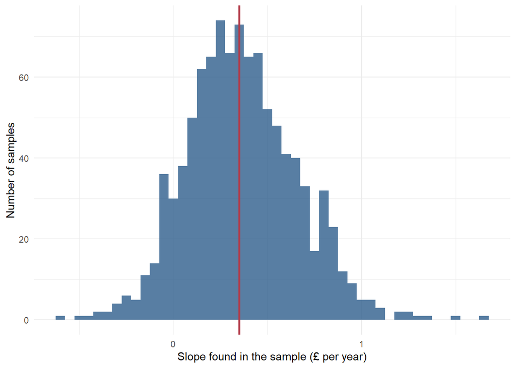

```r
ggplot(data.frame(slope = slopes), aes(x = slope)) +
  geom_histogram(binwidth = 0.05, fill = "#2E5E8C", alpha = 0.8) +
  geom_vline(xintercept = 0.35, color = "#B23A48", linewidth = 1) +
  labs(x = "Slope found in the sample (£ per year)", y = "Number of samples") +
  theme_minimal()
```

Each bar counts how many of our 1,000 samples gave a slope in that range. The red line is the true slope (0.35). Three things to notice:

1. The slopes are **centered on the true slope**. On average, a sample gets it right.
2. But each individual sample **misses it**, sometimes by a little, sometimes by a lot.
3. Some samples even give a **negative** slope (about 1 in 10). With one of these samples, you would have concluded that older passengers paid *less*. Pure bad luck.

**The standard error is the standard deviation of this distribution**: the typical distance between the slope found in one sample and the true slope.

```r
sd(slopes)
```

```
[1] 0.2929693
```

For samples of 100 passengers, the slope typically misses the true slope by about 0.29 £ per year. More precisely:

- about **two thirds** of samples give a slope within 1 standard error of the true slope;
- about **95%** of samples give a slope within 2 standard errors of the true slope.

Keep this second rule in mind: it’s the basis of the confidence interval (below).

**In real life**, we have only one sample, and we can’t redraw it 1,000 times. So R *estimates* what this spread would be, using only the sample we have. To do so, it uses three pieces of information:

- **the number of observations**: the more observations, the less a sample can be “unlucky”, so the smaller the standard error;
- **how scattered the dots are around the line**: the more scattered, the more the line could move from one sample to another, so the larger the standard error;
- **how spread out the values of x are**: a slope is easier to pin down over a wide range of ages than over a narrow one.

For our model `m1`, R estimates the standard error at 0.14. It’s smaller than the 0.29 of our simulation because `m1` uses 714 passengers, not 100: bigger samples give more precise slopes.

*NB: It’s an estimate: R’s standard error is usually close to the true spread, but never exactly equal to it.*

**How to say it:**

> ✅ “The slope is 0.35 £ per year, with a standard error of 0.14 £ per year.”

And if you need to explain what it means:

> ✅ “If we repeated the study on other random samples of 714 passengers, the slope we would find would typically differ from the true slope by about 0.14 £ per year.”

Notice that the standard error is in the **same units as the slope** (£ per year).

**Traps:**

> ❌ “The standard error measures how scattered the data are.” / “It’s the average distance between the dots and the line.”

No. The standard error is about the **slope**, not about the dots. It tells you how much the *slope* would move from one sample to another. Careful: the output of `summary()` contains a line called `Residual standard error` (here, 52.7). Despite the name, this is something else: it measures how far the dots typically are from the line. It’s not the standard error of the slope.

> ❌ “A small standard error means a strong relationship.”

No. The standard error measures **precision**, not strength. With a huge sample, you can estimate a tiny, meaningless slope very precisely (small standard error). Strength → look at the slope and R².

### The 95% confidence interval

**What it is.** The standard error is hard to read on its own. The confidence interval turns it into something concrete: a **range of plausible values for the true slope**.

**How it’s built.** Remember the rule: about 95% of samples give a slope within 2 standard errors of the true slope. Now flip it around: if our slope is within 2 standard errors of the true slope, then the true slope is within 2 standard errors of our slope. So we build the interval by going 2 standard errors down and 2 standard errors up from our estimate:

$$\text{estimate} \pm 2 \times \text{standard error}$$

Here: 0.35 ± 2 × 0.14, so roughly from 0.08 to 0.62. R computes it exactly for you (it uses a multiplier slightly below 2, but the idea is the same):

```r
confint(m1)
```

```
                  2.5 %     97.5 %
(Intercept) 15.48135132 33.1204516
Age          0.08316492  0.6167624
```

**What “95%” means, precisely.** This is the subtle part. Let’s go back to our simulation, where we know the true slope (0.35). We draw 50 samples of 100 passengers, and for each sample, we compute its 95% confidence interval:

*(Again, you don’t need to understand this code. Look at the result.)*

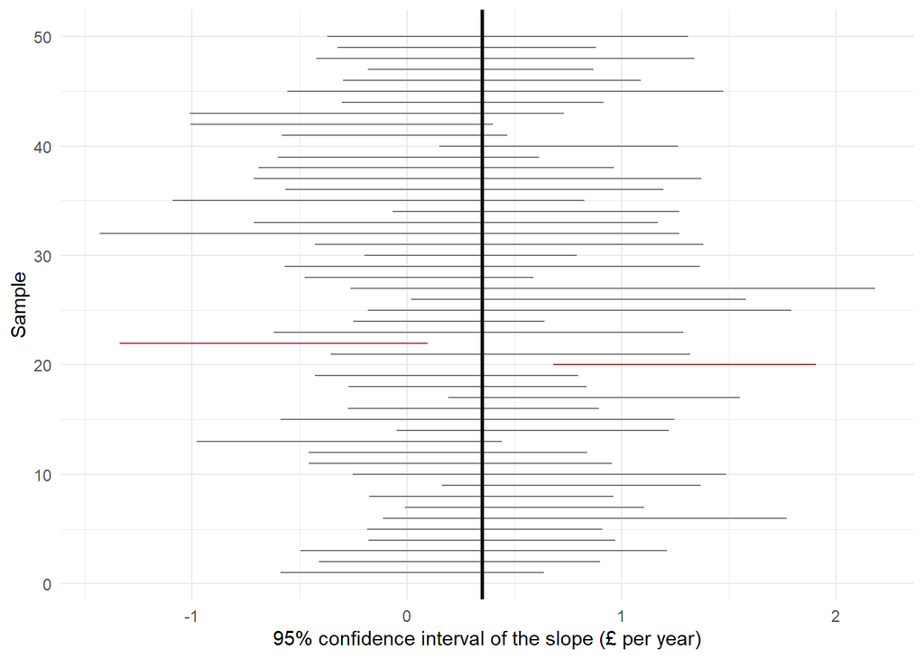

```r
set.seed(1)
intervals = data.frame(sample = 1:50, lower = NA, upper = NA)
for (i in 1:50) {
  one_sample = population %>% slice_sample(n = 100)
  ci = confint(lm(Fare ~ Age, data = one_sample))["Age", ]
  intervals$lower[i] = ci[1]
  intervals$upper[i] = ci[2]
}

intervals = intervals %>%
  mutate(contains_true_slope = lower <= 0.35 & upper >= 0.35)

ggplot(intervals, aes(x = lower, xend = upper, y = sample, yend = sample,
                      color = contains_true_slope)) +
  geom_segment() +
  geom_vline(xintercept = 0.35, linewidth = 1) +
  scale_color_manual(values = c("TRUE" = "grey50", "FALSE" = "#B23A48")) +
  labs(x = "95% confidence interval of the slope (£ per year)", y = "Sample") +
  theme_minimal() +
  theme(legend.position = "none")
```

Each horizontal line is the confidence interval of one sample. The black vertical line is the true slope. The grey intervals “catch” the true slope; the red ones miss it. Here, 48 out of 50 catch it: about 95%.

That’s what “95%” means: **it’s the success rate of the method**. If you build confidence intervals this way, 95% of them will contain the true value, and 5% won’t. In real life, you have only one interval, and you can never know whether yours is a grey one or a red one. You just know that the method works 95% of the time.

**How to say it:**

> ✅ “The 95% confidence interval for the slope goes from 0.08 to 0.62 £ per year.”

> ✅ “Our data are compatible with a true slope anywhere between 0.08 and 0.62 £ per year.”

You’ll also often read “we are 95% confident that the true slope is between 0.08 and 0.62”. It’s acceptable, as long as you remember that “95% confident” refers to the success rate of the method, not to a probability about this particular interval.

**The link with the p-value.** If 0 is **outside** the 95% confidence interval, the p-value is below 0.05, and vice versa. Here, both bounds are positive: 0 is not a plausible value for the true slope, and indeed p = 0.01. So the confidence interval gives you the same information as the p-value, and more: it also tells you which values *are* plausible.

**What makes an interval narrow or wide.** Exactly the same things as the standard error: more observations → narrower interval; more scattered dots → wider interval. A narrow interval means a precise estimate.

**Traps:**

> ❌ “There is a 95% probability that the true slope is between 0.08 and 0.62.”

Not exactly. The true slope is one fixed number: either it’s in this interval, or it isn’t. The 95% describes the method (95% of intervals built this way catch the true value), not this particular interval.

> ❌ “The interval contains 0, so there is no relationship.”

If 0 is in the interval, it means we **can’t rule out** that the true slope is 0. But the interval also contains other values, sometimes far from 0. “No relationship” is just one of the plausible values, not the conclusion.

### The `t value` column

It’s the estimate divided by its standard error (0.35 / 0.14 ≈ 2.6): how many standard errors the slope is away from zero. It’s the intermediate step R uses to compute the p-value. For now, you don’t need to pay attention to it.

## 2.6 A categorical predictor (dummy coding)

The predictor doesn’t have to be continuous. Question: **did men and women pay different fares?**

```r
m2 = lm(Fare ~ Sex, data = data)
summary(m2)
```

```
Call:
lm(formula = Fare ~ Sex, data = data)

Residuals:
   Min     1Q Median     3Q    Max
-37.73 -18.40 -16.76   2.70 486.81

Coefficients:
            Estimate Std. Error t value Pr(>|t|)
(Intercept)   44.480      2.759  16.122  < 2e-16 ***
Sexmale      -18.956      3.428  -5.529 4.23e-08 ***
---
Signif. codes:  0 '***' 0.001 '**' 0.01 '*' 0.05 '.' 0.1 ' ' 1

Residual standard error: 48.89 on 889 degrees of freedom
Multiple R-squared:  0.03325,   Adjusted R-squared:  0.03216
F-statistic: 30.57 on 1 and 889 DF,  p-value: 4.231e-08
```

When the predictor is a category, R can’t multiply it by a slope (“female × 0.35” makes no sense). So it does something called **dummy coding**: it picks one category as the **baseline** (by default, the first in alphabetical order: here `female`), and estimates the difference between each other category and this baseline.

You can recognize the baseline because it’s the category that **doesn’t appear** in the output: we see `Sexmale`, but no `Sexfemale`.

The interpretation changes compared to a continuous predictor:

- **Intercept** = the mean fare of the baseline group (here, women).

> ✅ “On average, women paid 44.5 £.”
- **`Sexmale`** = the *difference* between the mean of men and the baseline group (women).

> ✅ “On average, men paid 19 £ less than women.”

So the mean for men is 44.5 − 19 ≈ 25.5 £. You can check that these are exactly the group means:

```r
data %>%
  group_by(Sex) %>%
  summarise(mean_fare = mean(Fare))
```

| Sex | mean_fare |
| --- | --- |
| female | 44.47982 |
| male | 25.52389 |

- **The p-value of `Sexmale`** tests whether the difference between men and women could be zero in the population.

> ✅ “If men and women paid the same fare on average in the population, it would be extremely unlikely to observe a difference as large as 19 £ in a sample like ours (p < 0.001).”

**Trap:**

> ❌ “Being a man is associated with a fare of −19 £.”

No: −19 is a *difference*, compared to women. Nobody paid a negative fare.

*NB: With a two-category predictor, the p-value of the slope is exactly the same as the one you’d get from a t-test comparing the two groups. A t-test is a special case of linear regression.*

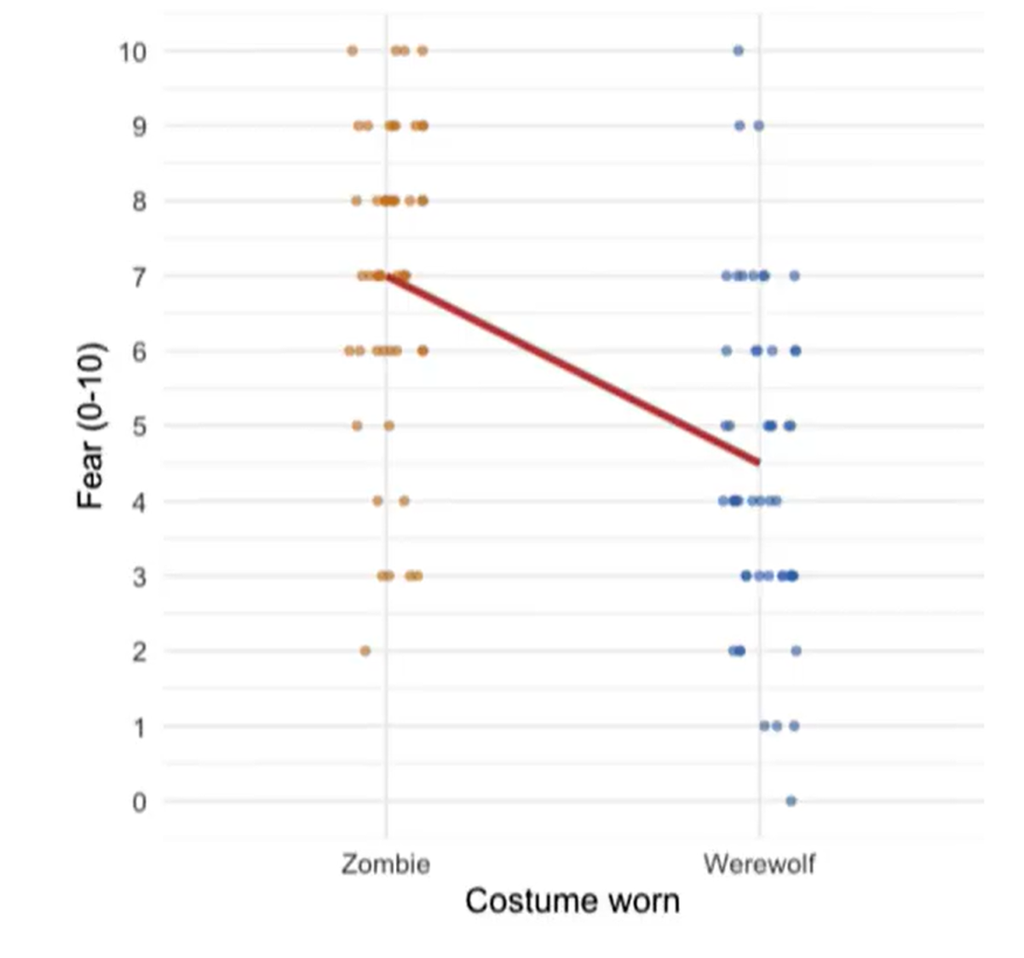

*Illustration of a linear model applied with a categorical predictor and a continuous outcome. Here, in the linear model Fear ~ Costume Worn, assuming that Zombie disguise is the baseline category, the Intercept will be the average perceived fear of Zombies and the slope will be the difference in mean perceived fear between Zombie and Werewolf costumes.*

## 2.7 Predictions

Once we have the equation of the line, we can predict y for any value of x. With `m1`, the equation is: Fare = 24.3 + 0.35 × Age. For a 50-year-old passenger: 24.3 + 0.35 × 50 ≈ 41.8 £.

R can do this for you with `predict()`. You give it the model, and a small dataset with the values of x you want predictions for. Here, we use the model `m1`, which predicts Fare from Age. So, if I give it values for Age, it can predict the Fare based on `m1`.

```r
predict(m1, newdata = data.frame(Age = c(20, 50)))
```

```
       1        2
31.30018 41.79909
```

> ✅ “The model predicts a fare of 31.3 £ for a 20-year-old passenger, and 41.8 £ for a 50-year-old passenger.”

Careful: a prediction is not the truth. It’s the value *on the line*. Real passengers are scattered around it, and the gap between the two is the residual (section 2.3). With an R² below 1%, our residuals are huge: knowing a passenger’s age barely helps predicting their fare.

*NB: Don’t predict outside the range of your data. Our passengers are between 0 and 80 years old: the model has no idea what a 120-year-old would pay, even though the equation will happily give you a number.*

## 2.8 The limits of a linear model

**It’s always a straight line.** By definition, OLS finds the best *straight* line. If the true relationship is curved (for instance, it increases fast and then flattens), the line won’t capture it: it will only give you the best straight approximation. It’s not the relationship that is linear: it’s you who decided to model it as linear. This is one more reason to always plot your data before (and after) fitting a model. If the cloud of dots clearly bends, a straight line is a poor summary.

**It’s sensitive to extreme values.** Because residuals are *squared*, a dot very far from the line weighs a lot in the sum: a residual of 10 counts 100, a residual of 100 counts 10,000. So a few extreme observations can pull the line toward them. In Titanic, the handful of passengers who paid more than 500 £ have a large influence on the line. Look at your scatterplot: are there isolated dots far from all the others?

**It shows associations, not causes.** A regression of y on x tells you how y and x move together. It never tells you that x *causes* y, however small the p-value.

# 3. Logistic regression

## 3.1 A binary outcome with `lm()`: the linear probability model

Linear regression works well when the outcome is a continuous variable, like a fare or an age. But very often, the outcome we care about is **binary**: survived or not, released or not, voted or not, employed or not. Coded 0 and 1.

Let’s take a question: **did passengers who paid more have a higher chance of surviving?** The simplest thing we can do is exactly what we did in section 2: fit a straight line with `lm()`. With a 0/1 outcome, this is called a **linear probability model** (LPM).

```r
m_linear = lm(Survived ~ Fare, data = data)
summary(m_linear)
```

```
Call:
lm(formula = Survived ~ Fare, data = data)

Residuals:
    Min      1Q  Median      3Q     Max
-0.9653 -0.3391 -0.3222  0.6044  0.6973

Coefficients:
             Estimate Std. Error t value Pr(>|t|)
(Intercept) 0.3026994  0.0187849  16.114  < 2e-16 ***
Fare        0.0025195  0.0003174   7.939 6.12e-15 ***
---
Signif. codes:  0 '***' 0.001 '**' 0.01 '*' 0.05 '.' 0.1 ' ' 1

Residual standard error: 0.4705 on 889 degrees of freedom
Multiple R-squared:  0.06621,   Adjusted R-squared:  0.06516
F-statistic: 63.03 on 1 and 889 DF,  p-value: 6.12e-15
```

**Why it’s so easy to interpret.** When the outcome is binary, everything reads directly in **predicted** **probabilities**:

- **The intercept** (0.30) is the predicted probability of survival for a passenger who paid 0 £: 30%.
- **The slope** (0.0025) is the change in the probability of survival for each additional pound: +0.0025, i.e. **+0.25 percentage points**. For 10 £ more: +2.5 percentage points.

> ✅ “On average, each additional 10 £ paid is associated with a probability of survival 2.5 percentage points higher.”

It works just as well with a categorical predictor:

```r
m_linear_sex = lm(Survived ~ Sex, data = data)
coef(m_linear_sex)
```

```
(Intercept)     Sexmale
  0.7420382  -0.5531301
```

- **The intercept** (0.74) is the probability of survival of the baseline group: 74% of women survived.
- **`Sexmale`** (−0.55) is the difference: men’s probability of survival was 55 percentage points lower (19% vs 74%).

> ✅ “Men’s probability of survival was 55 percentage points lower than women’s.”

That’s the great strength of the linear probability model: the coefficients are directly **changes in probability**, which everybody understands.

*NB: “Percentage points” vs “percent”. When a probability goes from 20% to 30%, it increases by 10 **percentage points** (30 − 20 = 10). But it increases by 50 **percent** (it’s 1.5 times bigger). These are two very different statements.*

## 3.2 The limits of the linear probability model

So why not always use `lm()`? Let’s plot the line:

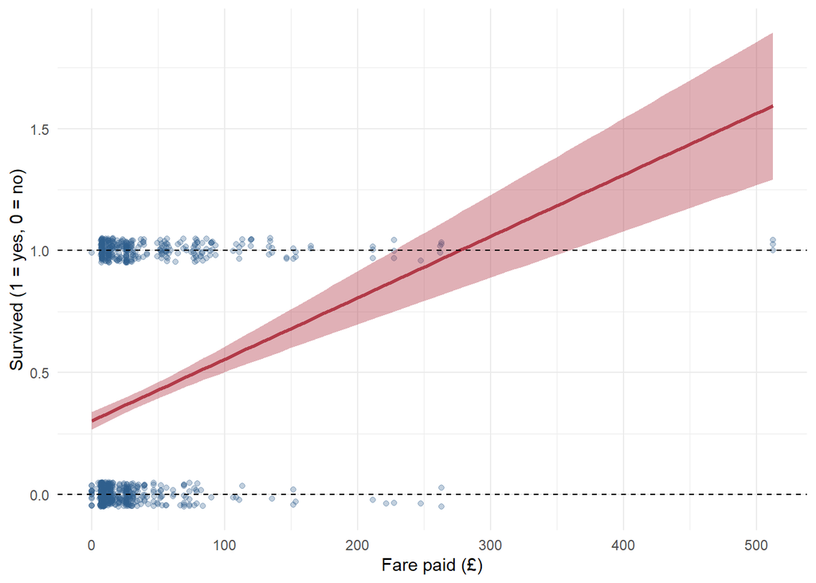

```r
ggplot(data, aes(x = Fare, y = Survived)) +
  geom_jitter(height = 0.05, alpha = 0.3, color = "#2E5E8C") +
  geom_smooth(method = "lm", color = "#B23A48", fill = "#B23A48") +
  geom_hline(yintercept = c(0, 1), linetype = "dashed") +
  labs(x = "Fare paid (£)", y = "Survived (1 = yes, 0 = no)") +
  theme_minimal()
```

Look at the right of the plot: the line goes **above 1**. Let’s ask the model what it predicts for a passenger who paid 300 £, and for the one who paid 512 £:

```r
predict(m_linear, newdata = data.frame(Fare = c(300, 512)))
```

```
       1        2
1.058554 1.592692
```

**Problem 1: impossible predictions.** A “probability” of survival of 1.06, and 1.59. That’s impossible: a probability can’t be higher than 1, or lower than 0. A straight line goes on forever, in both directions. Sooner or later, it leaves the 0–1 range.

**Problem 2: the same effect everywhere.** A straight line has one single slope: +2.5 percentage points for each 10 £, whatever the starting point. But think about it. A passenger whose probability of survival is 45% can gain a lot from paying more. A passenger whose probability is already 97% can’t gain 2.5 more points forever: there’s a ceiling at 100%. In reality, the closer you get to 0% or 100%, the smaller the changes in probability *must* become.

What we want instead is a line that **bends**: steep in the middle, and flattening as it gets close to 0 or 1, without ever crossing them. Something shaped like an S. That’s what logistic regression gives us.

**A logistic regression fits an S-curve to the data.** That’s the model: for each fare, the S-curve gives a predicted probability of survival, always between 0 and 1:

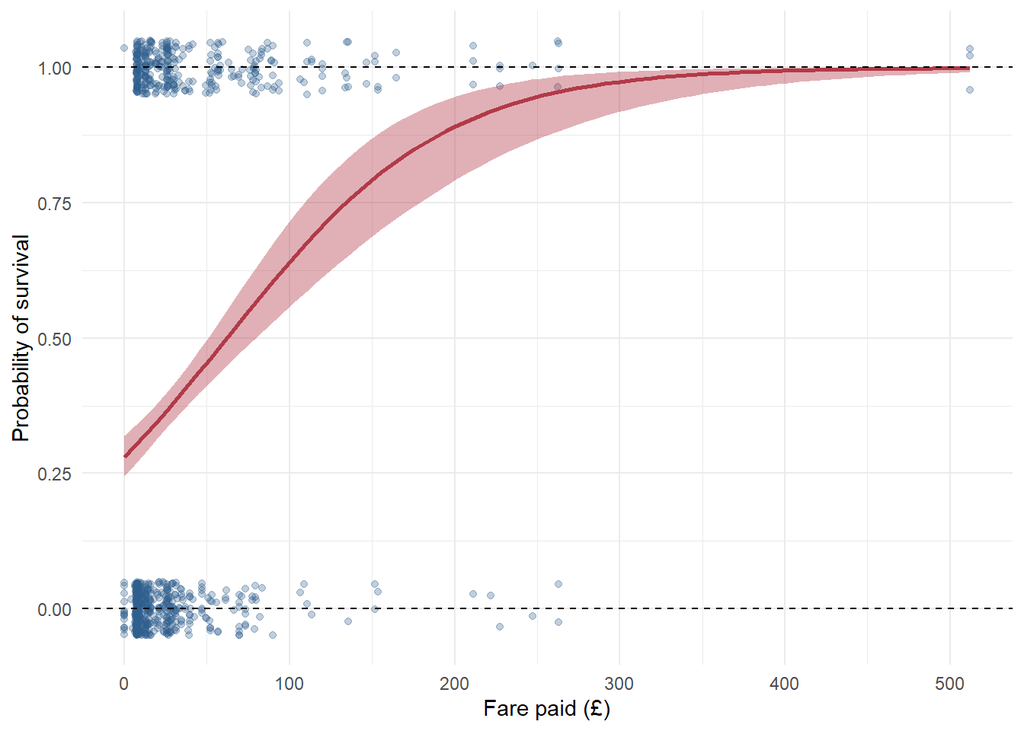

```r
ggplot(data, aes(x = Fare, y = Survived)) +
  geom_jitter(height = 0.05, alpha = 0.3, color = "#2E5E8C") +
  geom_smooth(method = "glm", method.args = list(family = "binomial"),
              color = "#B23A48", fill = "#B23A48") +
  geom_hline(yintercept = c(0, 1), linetype = "dashed") +
  labs(x = "Fare paid (£)", y = "Probability of survival") +
  theme_minimal()
```

Each point of the curve is a **predicted probability of survival** for a given fare. The curve rises at first, then flattens as it gets close to 1, without ever crossing it.

*NB: The linear probability model is not a crime. Many researchers use it, precisely because it’s so easy to interpret. In addition, it actually works well when the predicted probabilities stay far from 0 and 1. You can use it if your absolute priority is the interpretability of the result. But generally, especially if you want reliable predictions, or when your probabilities get close to 0 or 1, we use a logistic regression.*

## 3.3 What a logistic regression is

Let’s recap: we want a curve that stays between 0 and 1, flattens near both ends, and goes smoothly up (or down) in the middle. An **S-curve**.

But “draw an S” is not a model: we need a mathematical formula, just like for linear regression. In linear regression, a line is described by two numbers (intercept and slope), and R finds the best pair. We want the same here: a formula with numbers that fully describes an S-curve. Once we have it, R will be able to find the best numbers (as it did when it found the best intercept and slope in lm).

How can we do that? Well, linear models were very easy and convenient to use. So ideally, we’d like to use a model that is mathematically like a linear model (*y = ax + b*). But again, remember our issue: a straight line can’t *be* a probability (it goes beyond 0 and 1).

But maybe it can describe **something else**, which we can then translate back into a probability. If we find the right “something else”, we keep everything we love about straight lines, and we get probabilities in the end.

Let’s look for that “something else”.

### What goes wrong with the probability itself

If we tried to fit a straight line directly to the probability:

$$\text{probability of survival} = a + b \times \text{fare}$$

the straight line can give any number, from −∞ to +∞. For large enough fares, we’d get probabilities above 1. For negative enough values, we’d get probabilities below 0. We saw that in section 3.2: a passenger who paid 512 £ got a predicted “probability” of 1.59.

The problem is that a probability is bounded on **both sides** (between 0 and 1), while a straight line isn’t bounded at all. There’s no way to force the line to stop at 1 without breaking it. So the probability itself can’t be the thing we fit a line to. We need to find a quantity that **carries the same information as the probability**, but has **no limits**. Then we can fit a straight line to that quantity, with no risk of impossible values.

### First try: the odds

Here is a quantity that carries exactly the same information as the probability: the **odds**. The odds are the number of times something happens divided by the number of times it doesn’t:

$$\text{odds} = \frac{p}{1 - p}$$

If 3 passengers out of 4 survive, the **probability** of survival is 3/4 = 0.75.

In that case, the “**odds** of survival” is: 0.75/1-0.75 = 0.75/0.25 = 3. The way to formulate an odds is the formulation that you can hear in bets: we say that the odds of survival are 3 to 1. Or, put differently, that the odds of surviving are 3 times higher than the odds of not surviving.

The odds and the probability are two different ways of writing the same chances: from one, you can recover the other.

What did we gain by moving from probabilities to odds? The **ceiling at 1 is gone**. When the probability gets close to 1, the odds become huge. A probability of 0.9 gives odds of 9. A probability of 0.99 gives odds of 99. A probability of 0.999 gives odds of 999. So on the odds scale, our straight line can go up as high as it wants.

But there’s a catch. The odds still have a **floor at 0**: they can’t be negative (both the numerator and the denominator of p / (1 − p) are positive). So fitting a straight line to the odds would still produce impossible values on the low side.

We need one more move.

### Second try: the log-odds

Take the logarithm of the odds. The logarithm has a very useful property: it turns a floor at 0 into no floor at all. You might remember this from your high school classes:

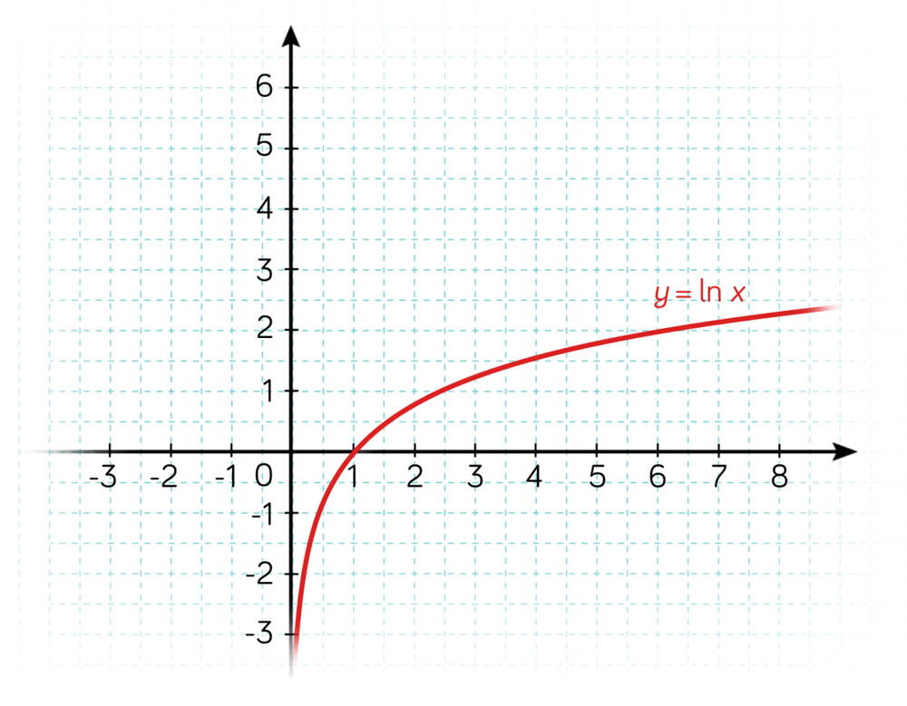

The logarithm of numbers close to 0 is very negative; the logarithm of large numbers is very positive, and most importantly the spectrum of a logarithm covers everything from - infinity to + infinity.

If we apply the logarithm function on odds, we obtain log-odds:

$$\text{log-odds} = \log\left(\frac{p}{1 - p}\right)$$

Now the log-odds can take **any** value, from −∞ to +∞. The ceiling and the floor are both gone, and we can finally fit a straight line without ever producing impossible values.

The three scales still carry exactly the same information:

| Probability | Odds | Log-odds |
| --- | --- | --- |
| 0.10 | 0.11 | −2.2 |
| 0.25 | 0.33 | −1.1 |
| 0.50 | 1 | 0 |
| 0.75 | 3 | 1.1 |
| 0.90 | 9 | 2.2 |

Low probability → negative log-odds. 50% → log-odds of 0. High probability → positive log-odds. From any one of the three columns, you can get back the two others.

### The logistic regression equation

So here’s the model. Instead of fitting a straight line to the probability, we fit a straight line to the **log-odds**:

$$\log\left(\frac{p}{1 - p}\right) = a + b \times \text{fare}$$

That’s a logistic regression. It’s just a linear regression, done on the log-odds instead of the raw outcome. The intercept a and the slope b have the usual meaning, except that they describe how the **log-odds** of survival change with fare, not how the probability does.

**In sum:**

*When you run a logistic regression, this is exactly what’s happening! The slope gives you how much an additional unit of the predictor x increases the log-odds of the outcome y. And the intercept gives you the log-odds of outcome y when x = 0.*

Hurray! What we gained from doing all this, is that we can model the relationship between a predictor and a binary outcome (e.g. Survived or not), with a simple linear regression, but without making wrong predictions (like probabilities above 1 or below 0). However, what we lose, is that now we have something that’s very difficult to interpret…

### Getting back to probabilities

The move from probability to log-odds was: take p / (1 − p), then take the logarithm. The reverse move is: take the exponential (the reverse of the logarithm), then isolate p. If you do the algebra (we won’t here), you get:

$$p = \frac{1}{1 + e^{-(a + b \times \text{fare})}}$$

So, for a given fare, the predicted probability of survival is this formula. Let’s see what it looks like. If we feed it with values of $a + b \times \text{fare}$ going from −6 to +6, we get a curve:

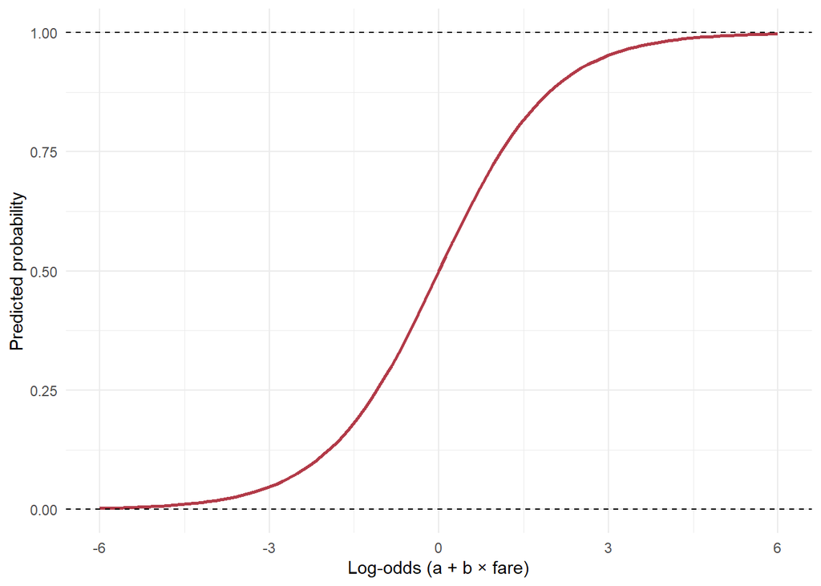

```r
ggplot(data.frame(log_odds = c(-6, 6)), aes(x = log_odds)) +
  stat_function(fun = function(x) 1 / (1 + exp(-x)),
                color = "#B23A48", linewidth = 1) +
  geom_hline(yintercept = c(0, 1), linetype = "dashed") +
  labs(x = "Log-odds (a + b × fare)", y = "Predicted probability") +
  theme_minimal()
```

An S. The curve we were looking for. Very negative log-odds give a probability close to 0; a log-odds of 0 gives a probability of 0.5; very positive log-odds give a probability close to 1, but never above.

So **a logistic regression is nothing more than a straight line, drawn on the log-odds scale, and then translated back into probabilities with the formula above**. The S-shape we see on the plot is just the shape of this translation.

Two numbers, a and b, fully describe this curve, exactly like for a straight line:

- **a** decides where the S sits (shift it left or right by changing a);
- **b** decides how steeply it rises (bigger b → steeper S; negative b → the S goes down).

Here are three S-curves with the same a (−3) and different values of b:

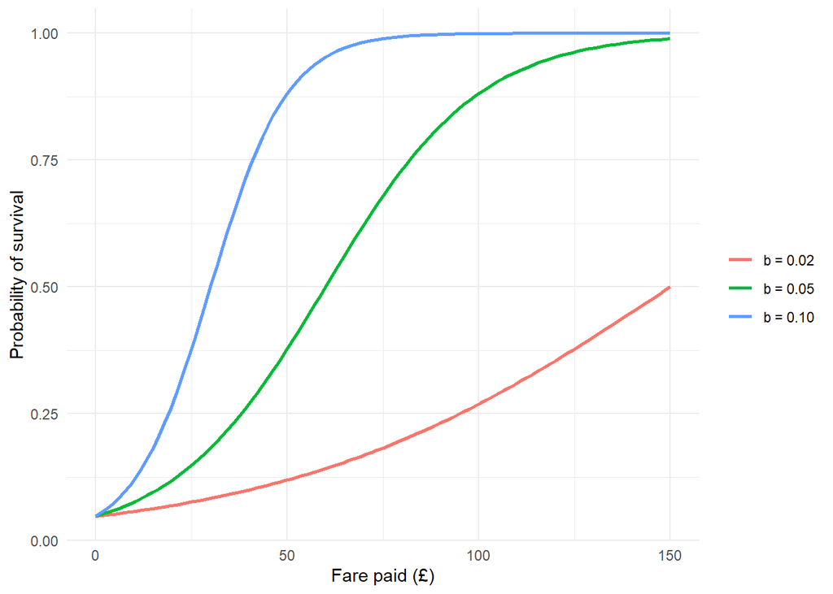

```r
ggplot(data.frame(Fare = c(0, 150)), aes(x = Fare)) +
  stat_function(fun = function(x) 1 / (1 + exp(-(-3 + 0.02 * x))),
                aes(color = "b = 0.02"), linewidth = 1) +
  stat_function(fun = function(x) 1 / (1 + exp(-(-3 + 0.05 * x))),
                aes(color = "b = 0.05"), linewidth = 1) +
  stat_function(fun = function(x) 1 / (1 + exp(-(-3 + 0.10 * x))),
                aes(color = "b = 0.10"), linewidth = 1) +
  labs(x = "Fare paid (£)", y = "Probability of survival", color = "") +
  theme_minimal()
```

**Fitting a logistic regression means finding the a and b whose S-curve fits the data best** (section 3.4 explains how). These two numbers are what R reports in the output: a is the intercept, b is the slope.

### Why the output is in log-odds

The intercept and the slope that R gives us are the a and b of the straight line we drew on the **log-odds scale**. That’s what the model is literally built on. They are not probabilities, and reading them as probabilities is wrong.

To get back to probabilities, we always do the same thing: plug a and b into $\frac{1}{1 + e^{-(a + b \times \text{fare})}}$. In practice, R does this for us (section 3.6).

### Translating between the three scales in R

You’ll need three R functions to move between probabilities, odds and log-odds:

- from **log-odds to probability**: `plogis()`. This is R’s name for the formula $\frac{1}{1 + e^{-x}}$: give it a log-odds, it gives you back a probability;
- from **probability to log-odds**: `qlogis()`. The reverse: it computes $\log(p / (1 - p))$ for you;
- from **log-odds to odds**: `exp()` (the exponential, the reverse of the logarithm).

Let’s check them against the table above:

```r
plogis(1.1)  # log-odds 1.1 -> probability
```

```
[1] 0.7502601
```

```r
qlogis(0.75) # probability 0.75 -> log-odds
```

```
[1] 1.098612
```

```r
exp(1.1)     # log-odds 1.1 -> odds
```

```
[1] 3.004166
```

## 3.4 How the curve is chosen: maximum likelihood

In section 3.3, we found the formula of our S-curve: it’s described by two numbers, a and b, exactly like a straight line. We now need to find the a and b that fit **our** data best. For a linear regression, OLS searched the best pair by minimizing the sum of squared residuals.

We need a different criterion here, because for a binary outcome, “the distance between the dot and the line” isn’t very meaningful: each dot is either 0 or 1. This criterion is called maximum likelihood.

**The idea.** For each passenger, a candidate S-curve gives a predicted probability of survival. Compare it with what *actually* happened to that passenger, and ask: **how much probability did the curve give to what really happened?**

- If the passenger **survived**, we look at the predicted probability of surviving.
- If the passenger **died**, we look at the predicted probability of dying (1 − the probability of surviving).

A good curve gives **high** probabilities to what really happened: it is not surprised by the data. A bad curve gives **low** probabilities to what really happened: it is constantly surprised.

Let’s see it on 4 passengers, with two candidate curves:

- **Curve A**: a flat curve, giving everybody a 50% chance of survival, whatever the fare.
- **Curve B**: a curve with a = −3 and b = 0.05.

```r
four = data.frame(Fare = c(10, 20, 80, 150),
                  Survived = c(0, 0, 1, 1))

four %>%
  mutate(prob_survival_A = 0.5,
         prob_survival_B = plogis(-3 + 0.05 * Fare),
         prob_what_happened_A = ifelse(Survived == 1, prob_survival_A, 1 - prob_survival_A),
         prob_what_happened_B = ifelse(Survived == 1, prob_survival_B, 1 - prob_survival_B))
```

| Fare | Survived | prob_survival_A | prob_survival_B | prob_what_happened_A | prob_what_happened_B |
| --- | --- | --- | --- | --- | --- |
| 10 | 0 | 0.5 | 0.0758582 | 0.5 | 0.9241418 |
| 20 | 0 | 0.5 | 0.1192029 | 0.5 | 0.8807971 |
| 80 | 1 | 0.5 | 0.7310586 | 0.5 | 0.7310586 |
| 150 | 1 | 0.5 | 0.9890131 | 0.5 | 0.9890131 |

The two passengers who paid little died: curve B gave them a *high* probability (0.92 and 0.88) to what really happened. The two who paid a lot survived: curve B gave them a high probability of surviving too (0.73 and 0.99). Curve A gives 0.5 to everyone: never very wrong, but never right either.

**Combining the four scores.** To rank the two curves, we want one single score per curve. We get it by multiplying these probabilities together. The result is called the **likelihood** of the curve: it tells us how likely the whole dataset, exactly as we observed it, is under that curve.

```r
four %>%
  mutate(prob_survival_A = 0.5,
         prob_survival_B = plogis(-3 + 0.05 * Fare),
         prob_what_happened_A = ifelse(Survived == 1, prob_survival_A, 1 - prob_survival_A),
         prob_what_happened_B = ifelse(Survived == 1, prob_survival_B, 1 - prob_survival_B)) %>%
  summarise(likelihood_A = prod(prob_what_happened_A),
            likelihood_B = prod(prob_what_happened_B))
```

| likelihood_A | likelihood_B |
| --- | --- |
| 0.0625 | 0.5885301 |

Curve B makes the observed data almost 10 times more likely than curve A. It fits much better.

**Fitting the model.** R does the same for all possible pairs (a, b), and keeps the pair with the **highest likelihood**: the curve under which the data we actually observed is the most likely to have happened. This criterion is called **maximum likelihood**.

So, side by side:

|  | Linear regression | Logistic regression |
| --- | --- | --- |
| Model | A straight line | An S-curve |
| Fitting criterion | OLS: minimize the sum of squared residuals | Maximum likelihood: maximize the likelihood of the data |
| Common idea | Among all possible lines/curves, keep the one that fits the data best |  |

*NB: With hundreds of observations, the likelihood becomes an extremely small number (you multiply hundreds of probabilities below 1). That’s why R actually works with its logarithm, the “log-likelihood”. You don’t need to worry about it: just know that it’s the same idea.*

## 3.5 Fit a model: `glm()`

The function is `glm()`, for “generalized linear model”. The syntax is the same as `lm()`, with one addition: `family = binomial`, which tells R that the outcome is binary (0/1), and that we want a logistic regression.

```r
m3 = glm(Survived ~ Fare, family = binomial, data = data)
summary(m3)
```

```
Call:
glm(formula = Survived ~ Fare, family = binomial, data = data)

Coefficients:
             Estimate Std. Error z value Pr(>|z|)
(Intercept) -0.941330   0.095129  -9.895  < 2e-16 ***
Fare         0.015197   0.002232   6.810 9.79e-12 ***
---
Signif. codes:  0 '***' 0.001 '**' 0.01 '*' 0.05 '.' 0.1 ' ' 1

(Dispersion parameter for binomial family taken to be 1)

    Null deviance: 1186.7  on 890  degrees of freedom
Residual deviance: 1117.6  on 889  degrees of freedom
AIC: 1121.6

Number of Fisher Scoring iterations: 4
```

*NB: If you forget `family = binomial`, `glm()` silently fits a plain linear regression. No error message: just the wrong model. Always check that you wrote it.*

*NB: The outcome must be coded 0/1 (or be a factor with two categories). If it’s “Yes”/“No” text, recode it first with `ifelse()`.*

The output looks like the one of `lm()`, with a few differences:

1. the **`Coefficients` table** is still there, with `Estimate`, `Std. Error`, `z value` (instead of `t value`) and `Pr(>|z|)` (the p-value);
2. there is **no R²**. Instead, you see `deviance` and `AIC`: they are measures of fit based on the likelihood. You can ignore them for now;
3. the `Estimate` column is **on the log-odds scale**. This is the big change, and the source of most mistakes.

## 3.6 Reading the output

As in section 2.5: for each element, what it is, **how to formulate it**, and **the traps to avoid**.

### The sign and the significance: read them directly

Before translating anything, two things can be read directly from the output, exactly as in a linear regression:

- **The sign of the slope.** Positive → the probability increases when x increases. Negative → it decreases. Here, the slope of `Fare` is positive (0.015): passengers who paid more were more likely to survive.
- **The p-value** (column `Pr(>|z|)`). Same definition as in section 2.5, same traps (re-read them!). Here, p < 0.001.

For many research questions, that’s already the main result. But to say *how much* more likely, we need to translate the numbers.

### The estimates are log-odds

The intercept (−0.94) and the slope (0.015) are the intercept and slope of the straight line on the log-odds scale. So: **each additional pound increases the log-odds of survival by 0.015.**

This sentence is correct, but nobody understands what “0.015 log-odds” means, including your readers. So we never report log-odds as they are. We translate them, in one of three ways: **odds ratios**, **predicted probabilities**, or **average marginal effects**.

**Trap:**

> ❌ “Each additional pound increases the probability of survival by 0.015 (or by 1.5 percentage points).”

No: 0.015 is not a probability, it’s a change in log-odds.

### Translation 1: odds ratios

**What it is:** on the log-odds scale, each additional pound *adds* 0.015. When we translate log-odds into odds with `exp()`, *adding* becomes *multiplying* (that’s what the exponential does). So on the odds scale, each additional pound *multiplies* the odds by a fixed number:

```r
exp(coef(m3))
```

```
(Intercept)        Fare
  0.3901087   1.0153129
```

The exponential of the slope is called an **odds ratio** (OR). Here, OR = 1.015. It tells you by how much **the odds** are *multiplied* when x increases by one unit.

- OR > 1: the odds increase (here, × 1.015 for each pound, i.e. the odds increase by 1.5%);
- OR < 1: the odds decrease (e.g. OR = 0.80 means the odds are multiplied by 0.80, i.e. the odds decrease by 20%);
- OR = 1: no relationship (multiplying by 1 changes nothing).

One pound is a small amount, so the OR is close to 1. It’s often clearer to express it for a more meaningful change, e.g. 10 £:

```r
exp(coef(m3)["Fare"] * 10)
```

```
    Fare
1.164124
```

**How to say it:**

> ✅ “Each additional pound paid multiplies the odds of survival by 1.015, i.e. increases the odds of survival by 1.5%.”

> ✅ “Each additional 10 £ paid multiplies the odds of survival by 1.16, i.e. increases the odds of survival by 16%.”

**Why “the odds increase by 1.5%” is NOT “the probability increases by 1.5%”.** The odds and the probability are two different scales, and moving by 1.5% on one doesn’t mean moving by 1.5% on the other. Let’s check it concretely. Take a passenger who paid 50 £, and look at what happens when the fare goes up by one pound:

```r
predict(m3, newdata = data.frame(Fare = c(50, 51)), type = "response")
```

```
        1         2
0.4547525 0.4585231
```

(We’ll see `predict()` in detail just below: for now, these are the predicted probabilities for 50 £ and 51 £.)

- **The odds** go from 0.834 to 0.847: they are multiplied by 1.015, so **+1.5%**, as the odds ratio says.
- **The probability** goes from 45.5% to 45.9%: **+0.4 percentage points** (or +0.8% in relative terms). Neither of these is 1.5.

Now take a passenger who paid 300 £:

```r
predict(m3, newdata = data.frame(Fare = c(300, 301)), type = "response")
```

```
        1         2
0.9738582 0.9742423
```

- **The odds** are again multiplied by 1.015: **+1.5%**. The odds ratio is the same everywhere.
- **The probability** goes from 97.39% to 97.42%: only **+0.04 percentage points**, ten times less than at 50 £.

So the same “+1.5% in the odds” corresponds to very different changes in probability, depending on where you are on the S-curve. That’s exactly the bending we wanted (section 3.2): near 100%, the probability can’t move much anymore. The odds ratio is constant precisely because it’s measured on a scale (the odds) where the curve doesn’t bend.

**Traps:**

> ❌ “Each additional pound makes passengers 1.5% more likely to survive.” / “…increases the probability of survival by 1.5%.”

The OR is about **odds**, not probabilities. As we just saw, the change in probability is something else, and it’s not even the same for everyone. If you write “likely”, “chance” or “probability”, you’re talking about probabilities, and that’s wrong here. Always write “**the odds**”.

> ❌ “Each additional 10 £ increases the probability of survival by the same amount, whatever the fare.”

The OR is constant, but the change in **probability** is not: it’s large in the middle of the S-curve, and tiny at the extremes.

**In sum:**

Ideally, we’d like to work with probabilities, because they’re the most intuitive kinds of findings. We want to be able to say: “an additional 100$ increases the probability of survival by x%”.

### Translation 2: predicted probabilities

**What it is:** the most intuitive way to communicate a logistic regression is to go all the way back to probabilities: what is the predicted probability of survival for a passenger who paid 10 £? 50 £? 100 £? This is simply reading the S-curve at different points.

`predict()` does it, with one essential addition: `type = "response"`.

```r
predict(m3, newdata = data.frame(Fare = c(10, 50, 100, 300, 500)), type = "response")
```

```
        1         2         3         4         5
0.3123058 0.4547525 0.6406892 0.9738582 0.9987168
```

**How to say it:**

> ✅ “The model predicts a probability of survival of 31% for a passenger who paid 10 £, 45% for 50 £, 64% for 100 £, 97% for 300 £, and 99% for 500£”

Notice how the S-curve shows up in the numbers: from 10 to 50 £, the probability gains 14 points; from 100 to 300 £, it gains 33 points over a much wider range, and then it’s almost stuck at 100%.

**Traps:**

> ❌ Forgetting `type = "response"`.

Without it, `predict()` gives you **log-odds**, not probabilities, without any warning. If you get negative numbers or numbers above 1, that’s what happened.

### Translation 3: average marginal effects (AME)

**The problem with predicted probabilities.** They are very clear, but they have two limits:

1. **They depend on the values you choose.** Why 10, 50, 100, 300 and 500 £? Someone else would pick other values, and tell a slightly different story.
2. **They don’t give you one number.** With a linear probability model, we had one single, simple answer: “+2.5 percentage points per 10 £”. With predicted probabilities, we have a list of numbers, and the effect changes depending on where you look (which is normal: it’s a feature of the S-shape).

What we’d like is the best of both worlds: the **correct S-curve** of the logistic regression, but summarized in **one number, in percentage points**, like in the linear probability model. That’s what the **average marginal effect** (AME) does.

**The idea.** For each passenger in the data, ask the model: “if this passenger had paid 10 £ more, by how many percentage points would their predicted probability of survival change?” Each passenger gets their own answer, depending on where they are on the S-curve: large for those in the middle, tiny for those already close to 100%. Then, **average** all these answers. That average is the AME.

Let’s compute it by hand, step by step, to see that there is no magic:

```r
data %>%
  mutate(prob_now     = predict(m3, newdata = data, type = "response"),
         prob_plus_10 = predict(m3, newdata = mutate(data, Fare = Fare + 10), type = "response"),
         change       = prob_plus_10 - prob_now) %>%
  summarise(AME = mean(change) * 100) # in percentage points
```

| AME |
| --- |
| 3.382204 |

- `prob_now`: each passenger’s predicted probability, with their actual fare;
- `prob_plus_10`: the same passenger’s predicted probability if they had paid 10 £ more;
- `change`: the difference, for each passenger;
- `AME`: the average of these differences, over all passengers.

In practice, you don’t compute it by hand: the `marginaleffects` package does it for you, and also gives you a standard error, a p-value and a confidence interval.

```r
install.packages("marginaleffects") # once, in the console
```

```r
library(marginaleffects)
avg_comparisons(m3, variables = list(Fare = 10))
```

```
 Estimate Std. Error    z Pr(>|z|)    S  2.5 % 97.5 %
   0.0338    0.00457 7.41   <0.001 42.8 0.0249 0.0428

Term: Fare
Type: response
Comparison: +10
```

Same number: +3.4 percentage points, with a 95% confidence interval from 2.5 to 4.3 points.

**How to say it:**

> ✅ “On average, paying 10 £ more is associated with a probability of survival 3.4 percentage points higher (95% CI [2.5, 4.3]).”

It reads exactly like a linear probability model. But it’s computed from the logistic regression, so it respects the S-curve: no impossible predictions, and smaller changes for passengers already close to 0% or 100%.

*NB: Compare with the linear probability model of section 3.1: +2.5 points per 10 £. The two are often close, but not identical. Here they differ a bit, because the straight line was pulled by the few very expensive tickets (section 2.8).*

*NB: For a one-unit change, use `avg_slopes(m3)` instead. It gives the effect of one additional pound: here, +0.33 percentage points.*

**Traps:**

> ❌ “Paying 10 £ more increases every passenger’s probability of survival by 3.4 points.”

No: it’s an **average**. For passengers in the middle of the S-curve, the change is larger; for passengers already close to 100%, it’s tiny (+0.36 points at 300 £). The AME summarizes all of them in one number.

> ❌ “Paying 10 £ more increases the probability of survival by 3.4%.”

It’s 3.4 **percentage points**, not percent (see the NB in section 3.1).

> ❌ Forgetting that the AME depends on your sample.

The AME is an average over *your* observations. Since most Titanic passengers paid low fares, the AME mostly reflects what happens at low fares. In another population, with different fares, the same model could give a different AME.

### The intercept

**What it is:** the log-odds of survival when x = 0. Translated into a probability with `plogis()`, it’s the predicted probability of survival for a passenger who paid 0 £:

```r
plogis(coef(m3)["(Intercept)"])
```

```
(Intercept)
  0.2806318
```

**How to say it:**

> ✅ “For a passenger who paid 0 £, the predicted probability of survival is 28%.”

**Trap:** same as in linear regression. If x = 0 is impossible or outside your data, the intercept is just the anchor of the curve. (Here, a few passengers did travel for free, so it makes some sense.)

### Which number should I report?

- **In the text**, report the sign and the p-value, and at least one effect **in probabilities**: an AME, or predicted probabilities for a few meaningful values. That’s what your readers will understand.
- **Odds ratios** are common in some fields (medicine, epidemiology), so you need to be able to read them. But if you report them, always say “the odds”, and add probabilities next to them.
- **Never** report log-odds alone.

## 3.7 A categorical predictor

Question: **did men and women have the same chance of surviving?**

```r
m4 = glm(Survived ~ Sex, family = binomial, data = data)
summary(m4)
```

```
Call:
glm(formula = Survived ~ Sex, family = binomial, data = data)

Coefficients:
            Estimate Std. Error z value Pr(>|z|)
(Intercept)   1.0566     0.1290   8.191 2.58e-16 ***
Sexmale      -2.5137     0.1672 -15.036  < 2e-16 ***
---
Signif. codes:  0 '***' 0.001 '**' 0.01 '*' 0.05 '.' 0.1 ' ' 1

(Dispersion parameter for binomial family taken to be 1)

    Null deviance: 1186.7  on 890  degrees of freedom
Residual deviance:  917.8  on 889  degrees of freedom
AIC: 921.8

Number of Fisher Scoring iterations: 4
```

As in section 2.6, R uses dummy coding: `female` is the baseline (it doesn’t appear in the output), and `Sexmale` is the difference between men and women. The difference is that everything is on the log-odds scale. Let’s translate.

**The intercept** = the log-odds of survival for the baseline group (women). Translated into a probability with `plogis()`:

```r
plogis(coef(m4)["(Intercept)"])
```

```
(Intercept)
  0.7420382
```

> ✅ “The predicted probability of survival for women is 74%.”

**`Sexmale`** = the difference in log-odds between men and women. Translated into an odds ratio with `exp()`:

```r
exp(coef(m4))
```

```
(Intercept)     Sexmale
 2.87654321  0.08096732
```

> ✅ “The odds of survival of men were 0.08 times those of women, i.e. 92% lower.”

**The average marginal effect.** With a categorical predictor, the AME is simply the difference in predicted probability between the two groups:

```r
avg_comparisons(m4)
```

```
 Estimate Std. Error     z Pr(>|z|)     S  2.5 % 97.5 %
   -0.553     0.0296 -18.7   <0.001 256.7 -0.611 -0.495

Term: Sex
Type: response
Comparison: male - female
```

> ✅ “Men’s probability of survival was 55 percentage points lower than women’s (95% CI [−61, −50]).”

Exactly the same number as the linear probability model of section 3.1 (−0.55). With a single categorical predictor, the two approaches always agree: they both just compare the survival rates of the groups. You can check that these are indeed the survival rates of each group:

```r
data %>%
  group_by(Sex) %>%
  summarise(survival_rate = mean(Survived))
```

| Sex | survival_rate |
| --- | --- |
| female | 0.7420382 |
| male | 0.1889081 |

74% for women, 19% for men.

**Traps:** this example shows perfectly why odds and probabilities must not be confused.

> ❌ “Men were 0.08 times as likely to survive as women.”

No! In terms of probability, men were 0.19 / 0.74 ≈ **0.25** times as likely to survive: a quarter, not a twelfth. 0.08 is the ratio of the *odds*. Confusing the two makes the gap look three times bigger than it is.

> ❌ “Men were 92% less likely to survive.”

Same mistake: it’s the **odds** that are 92% lower. The probability is 74% lower in relative terms (from 0.74 to 0.19), or 55 percentage points lower.

## 3.8 Predictions

As we saw, `predict()` with `type = "response"` gives predicted probabilities:

```r
predict(m4, newdata = data.frame(Sex = c("female", "male")), type = "response")
```

```
        1         2
0.7420382 0.1889081
```

# 4. Special case: regression with categorical variables with more than two categories

In sections 2 and 3, we either worked with continuous predictors or categorical predictors with **two** categories (women / men). The output was easy: one baseline, one difference. But in real data, many categorical variables have three, four or more categories: passenger class (1st, 2nd, 3rd), political party, country of residence…

## 4.1 How R handles a predictor with more than two categories

To illustrate, let’s create the Class factor based on the Pclass variable:

```r
data = data %>%
  mutate(Class = factor(Pclass, levels = c(1, 2, 3),
                        labels = c("1st class", "2nd class", "3rd class")))
```

Take `Class`, with three categories: 1st class, 2nd class, 3rd class. What happens we use Class (or any other categorical variable with more than two categories) in a regression, linear or logistic? Well… Pretty much the same as with a binary predictor! R does the following two things:

- it picks **one** category as the **baseline** (by default, the first in alphabetical order: here 1st class);
- for each category outside of the baseline, it calculates the effect of being in that category compared to being in the baseline category (e.g. being 3rd class vs. being 1st class)

**NB:** This means that the results and their interpretation depend a lot on how you define the baseline! In R, this has two consequences:

- When you use a category as a predictor, it’s always better to use it as a *factor* variable. You can see how to use factor() in the chunk above.
- If you’re not satisfied with the default baseline in your factor, you then need to use relevel():

```r
data = data %>%
  mutate(Class = relevel(Class, ref = "1st class"))
#this code changes the baseline of Class to 1st class. Note: 1st class was already the default baseline, so here it's not changing anything.
```

- Or, you can do it directly when transforming your variable into a factor, by adding a level argument, like in the code below. In that case, the baseline will automatically be the first category (from left to right) and the remaining categories will appear in order:

```r
#Example: turning education into a factor and specifying the levels so they're not set by default
data = data %>%
  mutate(education = factor(education,
                            levels = c("none", "primary", "secondary", "tertiary")))
```

## 4.2 Linear regression

Question: **did fare depend on passenger class?** Let’s start with the group means, to know what we’re trying to predict:

```r
data %>%
  group_by(Class) %>%
  summarise(mean_fare = mean(Fare))
```

| Class | mean_fare |
| --- | --- |
| 1st class | 84.15469 |
| 2nd class | 20.66218 |
| 3rd class | 13.67555 |

1st class passengers paid on average 84 £, 2nd class 21 £, 3rd class 14 £. Now let’s fit the model:

```r
m5 = lm(Fare ~ Class, data = data)
summary(m5)
```

```
Call:
lm(formula = Fare ~ Class, data = data)

Residuals:
   Min     1Q Median     3Q    Max
-84.15  -6.93  -5.75   5.03 428.17

Coefficients:
               Estimate Std. Error t value Pr(>|t|)
(Intercept)      84.155      2.723   30.91   <2e-16 ***
Class2nd class  -63.493      4.014  -15.82   <2e-16 ***
Class3rd class  -70.479      3.267  -21.57   <2e-16 ***
---
Signif. codes:  0 '***' 0.001 '**' 0.01 '*' 0.05 '.' 0.1 ' ' 1

Residual standard error: 40.01 on 888 degrees of freedom
Multiple R-squared:  0.3531,    Adjusted R-squared:  0.3516
F-statistic: 242.3 on 2 and 888 DF,  p-value: < 2.2e-16
```

The logic is the same as with a binary predictor: the intercept tells us the mean output value for the baseline category, and the slopes tell us the difference in mean between the baseline and the category. Three lines in the output:

- **The intercept** (84.2): the mean of the baseline group. **1st class passengers paid 84 £ on average.**
- **`Class2nd class`** (−63.5): the *difference* between 2nd class and the baseline. **2nd class passengers paid 63 £ less than 1st class passengers on average**, so 84 − 63 = 21 £.
- **`Class3rd class`** (−70.5): the *difference* between 3rd class and the baseline. **3rd class passengers paid 70 £ less than 1st class passengers on average**, so 84 − 70 = 14 £.

NB: Results are a comparison with the **baseline**, not with the other non-baseline categories. The outputs tell us how 2nd and 3rd class compare to 1st class, but it doesn’t directly tell us how 2nd class compares to 3rd class.

## 4.3 Logistic regression

The logic is **exactly the same**, with the usual twist: everything in the output is on the log-odds scale, and we translate it back.

Question: **did survival depend on passenger class?** Group survival rates first:

```r
data %>%
  group_by(Class) %>%
  summarise(survival_rate = mean(Survived))
```

| Class | survival_rate |
| --- | --- |
| 1st class | 0.6296296 |
| 2nd class | 0.4728261 |
| 3rd class | 0.2423625 |

63% for 1st class, 47% for 2nd class, 24% for 3rd class. Now the model:

```r
m6 = glm(Survived ~ Class, family = binomial, data = data)
summary(m6)
```

```
Call:
glm(formula = Survived ~ Class, family = binomial, data = data)

Coefficients:
               Estimate Std. Error z value Pr(>|z|)
(Intercept)      0.5306     0.1409   3.766 0.000166 ***
Class2nd class  -0.6394     0.2041  -3.133 0.001731 **
Class3rd class  -1.6704     0.1759  -9.496  < 2e-16 ***
---
Signif. codes:  0 '***' 0.001 '**' 0.01 '*' 0.05 '.' 0.1 ' ' 1

(Dispersion parameter for binomial family taken to be 1)

    Null deviance: 1186.7  on 890  degrees of freedom
Residual deviance: 1083.1  on 888  degrees of freedom
AIC: 1089.1

Number of Fisher Scoring iterations: 4
```

Reading each line:

- **The intercept** (0.53) is the log-odds of survival for the baseline (1st class). It’s a log-odds on its own, so both translations make sense. We want a probability, so we use `plogis()`:

```r
plogis(coef(m6)["(Intercept)"])
```

```
(Intercept)
  0.6296296
```

**The predicted probability of survival for 1st class is 63%.** Matches the group rate.

- **`Class2nd class`** (−0.64) is a *difference* in log-odds between 2nd class and 1st class. A difference in log-odds is not a log-odds, so `plogis()` doesn’t apply here (there’s no single probability that corresponds to a difference — see the S-curve of section 3.3: the same change in log-odds gives different changes in probability depending on where you are). What `exp()` gives us is an **odds ratio**:

```r
exp(coef(m6)["Class2nd class"])
```

```
Class2nd class
     0.5275925
```

**The odds of survival of 2nd class passengers were 0.53 times those of 1st class passengers**, i.e. about 47% lower.

- **`Class3rd class`** (−1.67) is the same, for 3rd class vs 1st class. `exp(-1.67) ≈ 0.19`: **the odds of survival of 3rd class passengers were 0.19 times those of 1st class**, about 81% lower.

**To get the probability of 2nd and 3rd class**, we can’t just `plogis()` the difference. We need to first reconstruct the **log-odds** of these groups: baseline log-odds + difference = log-odds of this group. Then we can `plogis()` the result:

```r
plogis(coef(m6)["(Intercept)"] + coef(m6)["Class2nd class"]) # 2nd class
```

```
(Intercept)
  0.4728261
```

```r
plogis(coef(m6)["(Intercept)"] + coef(m6)["Class3rd class"]) # 3rd class
```

```
(Intercept)
  0.2423625
```

47% and 24%, exactly the group rates.

**How to say it:**

> ✅ “The predicted probability of survival was 63% for 1st class, 47% for 2nd class, and 24% for 3rd class. The odds of 2nd class passengers were half those of 1st class (OR = 0.53, p = 0.002), and the odds of 3rd class passengers were five times lower than 1st class (OR = 0.19, p < 0.001).”

# 5. Multiple regression

So far, every model has had **one** predictor. That’s enough to answer questions like “did older passengers pay more?” or “did men and women have the same chance of surviving?”. But most interesting questions involve several variables at once.

Why would we want to add more variables to the model?

- **To compare the effect of several variables on the same outcome.** Which was more important for survival: being a woman, or being in 1st class?
- **To get a fuller picture.** Age is only one piece of the fare story. Class and family size matter too. A model with several variables captures more of what’s going on.
- **To control for a variable.** We’ll come back to this one in section 5.4, because it’s both powerful and dangerous: it’s the main reason regression is used in the social sciences, and the main reason it’s often misused.

The good news: nothing new to learn. In R, you just add predictors with `+` on the right side of the `~`. Everything else — fitting, output, interpretation — works like we already know.

## 5.1 Linear regression with several predictors

Question: **do fares depend on age, taking passenger class into account?** In section 2, we found that each additional year of age was associated with +0.35 £ in fare. Let’s now add class to the model:

```r
m7 = lm(Fare ~ Age + Class, data = data)
summary(m7)
```

```
Call:
lm(formula = Fare ~ Age + Class, data = data)

Residuals:
   Min     1Q Median     3Q    Max
-88.08  -9.73  -3.89   4.95 423.23

Coefficients:
               Estimate Std. Error t value Pr(>|t|)
(Intercept)    107.5108     5.3972  19.920  < 2e-16 ***
Age             -0.5113     0.1162  -4.401 1.24e-05 ***
Class2nd class -70.7625     4.5219 -15.649  < 2e-16 ***
Class3rd class -81.4267     4.0789 -19.963  < 2e-16 ***
---
Signif. codes:  0 '***' 0.001 '**' 0.01 '*' 0.05 '.' 0.1 ' ' 1

Residual standard error: 41.81 on 710 degrees of freedom
  (177 observations effacées parce que manquantes)
Multiple R-squared:  0.3783,    Adjusted R-squared:  0.3757
F-statistic:   144 on 3 and 710 DF,  p-value: < 2.2e-16
```

The output is longer, but each line reads just like before, with **one crucial addition**: each coefficient is the effect of its variable *while holding the other variables constant*. In plain English: it’s the effect of this variable **among passengers who are otherwise similar on the other variables**.

- **The intercept** (107.5): the predicted fare for a passenger with age 0, in the baseline class (1st class). As usual, don’t over-interpret an intercept at impossible values of the predictors.
- **`Age`** (−0.51): among passengers **in the same class**, each additional year of age is associated with a fare 0.51 £ **lower**.
- **`Class2nd class`** (−70.8): among passengers **of the same age**, 2nd class passengers paid 70.8 £ less than 1st class passengers.
- **`Class3rd class`** (−81.4): among passengers of the same age, 3rd class passengers paid 81.4 £ less than 1st class.

**How to say it:**

> ✅ “Among passengers in the same class, each additional year of age is associated with a fare 0.51 £ lower (p < 0.001).”

> ✅ “Holding age constant, 3rd class passengers paid on average 81 £ less than 1st class passengers (p < 0.001).”

Notice the phrases “among passengers in the same class” and “holding age constant”. **These are not decorations: they’re part of the meaning of the coefficient.** Without them, your interpretation is wrong.

**Something strange happened to Age.** In the simple regression of section 2, the slope of `Age` was **+0.35**: older passengers paid *more*. Here, it’s **−0.51**: older passengers paid *less*. Same data, opposite conclusion! This isn’t a bug — it’s the whole reason multiple regression matters, and we’ll explain it in section 5.4.

## 5.2 Logistic regression with several predictors

The logic is exactly the same. Question: **did sex, class, and age all independently matter for survival?**

```r
m8 = glm(Survived ~ Sex + Class + Age, family = binomial, data = data)
summary(m8)
```

```
Call:
glm(formula = Survived ~ Sex + Class + Age, family = binomial,
    data = data)

Coefficients:
                Estimate Std. Error z value Pr(>|z|)
(Intercept)     3.777013   0.401123   9.416  < 2e-16 ***
Sexmale        -2.522781   0.207391 -12.164  < 2e-16 ***
Class2nd class -1.309799   0.278066  -4.710 2.47e-06 ***
Class3rd class -2.580625   0.281442  -9.169  < 2e-16 ***
Age            -0.036985   0.007656  -4.831 1.36e-06 ***
---
Signif. codes:  0 '***' 0.001 '**' 0.01 '*' 0.05 '.' 0.1 ' ' 1

(Dispersion parameter for binomial family taken to be 1)

    Null deviance: 964.52  on 713  degrees of freedom
Residual deviance: 647.28  on 709  degrees of freedom
  (177 observations effacées parce que manquantes)
AIC: 657.28

Number of Fisher Scoring iterations: 5
```

As usual, everything is on the log-odds scale. We translate with `exp()` to get odds ratios:

```r
exp(coef(m8))
```

```
   (Intercept)        Sexmale Class2nd class Class3rd class            Age
   43.68534331     0.08023617     0.26987422     0.07572664     0.96369033
```

Each coefficient is now interpreted **holding the other variables constant**:

- **`Sexmale`** (OR = 0.08): among passengers **of the same class and age**, the odds of survival of men were 0.08 times those of women, i.e. 92% lower.
- **`Class3rd class`** (OR = 0.08): among passengers **of the same sex and age**, 3rd class passengers had odds of survival 0.08 times those of 1st class passengers.
- **`Age`** (OR = 0.96): among passengers **of the same sex and class**, each additional year of age multiplies the odds of survival by 0.96, i.e. decreases them by about 4%.

As in section 3, odds ratios are hard to compare between variables. Predicted probabilities (or AMEs) are clearer. Here’s the AME of each predictor, using `marginaleffects`:

```r
library(marginaleffects)
avg_comparisons(m8)
```

[output not shown]

The results:

- being a man rather than a woman: **−47 percentage points** of probability of survival (holding class and age constant);
- being in 3rd class rather than 1st: **−42 percentage points** (holding sex and age constant);
- each additional year of age: **−0.5 percentage points** (holding sex and class constant).

**How to say it:**

> ✅ “Holding class and age constant, being a man (rather than a woman) is associated with a probability of survival 47 percentage points lower (p < 0.001). Holding sex and age constant, being in 3rd class (rather than 1st) is associated with a probability 42 percentage points lower (p < 0.001). Holding sex and class constant, each additional year of age is associated with a probability about 0.5 points lower (p < 0.001).”

Three honest sentences, three real findings.

## 5.3 Reading coefficients from a multiple regression

Three rules that always apply.

**Rule 1: always add “holding the other variables constant” when you interpret a coefficient.** Each coefficient answers a specific question: “if I compare two people who are identical on all the other variables, but who differ on this one, how much does the outcome differ?”. That’s a very different question from the one answered by a simple regression (“how much does the outcome differ between people who differ on this variable, period?”). Mixing the two is one of the most common mistakes in applied statistics.

**Rule 2: a coefficient can change — in size, in significance, even in sign — when you add or remove other variables.** We just saw it with age and fare: +0.35 alone, −0.51 after adding class. This is not a glitch, and it’s not that one of the two is “right” and the other “wrong”. They answer different questions. Which one you report depends on what you want to know (section 5.4).

**Rule 3: don’t compare coefficient sizes across different units.** In `m7`, the coefficient of `Age` (−0.51) is much smaller than that of `Class3rd class` (−81.4). This doesn’t mean class matters more than age: age is in years, class is a 0/1 jump between categories, and 0.51 £ per year × 60 years = 30 £, almost half of the class effect. To compare the importance of variables measured on different scales, use predicted probabilities, AMEs, or standardize the variables first (we won’t cover that here).

## 5.4 Confounds, controls, and the problem of “controlling for everything”

Let’s pose a new question: **did paying a higher fare, in itself, improve a passenger’s chance of surviving?** We saw in section 3 that yes, more expensive tickets came with higher survival. But why? There are at least two possible stories:

- **Story A:** fare itself helped survival — maybe it bought you something concrete, like a cabin close to the lifeboats, or priority in the evacuation.
- **Story B:** fare had no direct effect at all. Expensive tickets came with 1st class, and 1st class is what actually mattered — being on the upper decks, being evacuated first, etc. Fare just happened to be a label for class.

The simple regression `glm(Survived ~ Fare)` can’t tell these two apart. Let’s add class and see what happens:

```r
m_fare       = glm(Survived ~ Fare, family = binomial, data = data)
m_fare_class = glm(Survived ~ Fare + Class, family = binomial, data = data)

library(marginaleffects)
avg_comparisons(m_fare,       variables = list(Fare = 10))
```

```
 Estimate Std. Error    z Pr(>|z|)    S  2.5 % 97.5 %
   0.0338    0.00457 7.41   <0.001 42.8 0.0249 0.0428

Term: Fare
Type: response
Comparison: +10
```

```r
avg_comparisons(m_fare_class, variables = list(Fare = 10))
```

```
 Estimate Std. Error    z Pr(>|z|)   S   2.5 % 97.5 %
   0.0144    0.00505 2.86  0.00425 7.9 0.00454 0.0244

Term: Fare
Type: response
Comparison: +10
```

The AMEs for +10 £:

- **Without class:** +3.4 percentage points of survival per 10 £. That’s the raw effect we reported in section 3.
- **Controlling for class:** +1.4 percentage points per 10 £. The effect shrinks to less than half.

So most of what looked like “fare helping survival” was actually “class helping survival”. Among passengers **in the same class**, paying 10 £ more is only associated with a tiny 1.4-point gain. Class was doing most of the work, and fare was taking the credit.

### What just happened: a confound

Class is a **confound** for the relationship between fare and survival. A confound is a variable that is a **common cause** of both the predictor and the outcome:

- class influences fare (1st class tickets are expensive, 3rd class tickets are cheap);
- class influences survival (1st class passengers were evacuated first).

Because of this double link, class creates a **spurious statistical association** between fare and survival, on top of any direct effect fare may have. The simple regression lumps the two together. The multiple regression, by controlling for class, isolates the direct effect of fare.

### Drawing the problem: DAGs

To think clearly about confounding, researchers draw small diagrams called **DAGs** (Directed Acyclic Graphs). Each variable is a box, and each arrow means “causally influences”. Our situation looks like this:

```
            Class
           /     \
          v       v
        Fare ---> Survived (direct effect, if any)
```

There are two paths from Fare to Survived:

- the **direct path**: Fare → Survived (what we care about: does paying more, in itself, help?);
- the **back-door path**: Fare ← Class → Survived (the confounding path, through class).

The simple regression mixes both. Controlling for class **blocks the back-door path**, leaving only the direct one.

The rule of thumb: **a confound is a variable that influences both the predictor you care about and the outcome.** If you don’t control for it, the coefficient of your predictor absorbs the confound’s effect. If you do control for it, the coefficient reflects only the direct effect.

### “Controlling for” a variable

**Controlling for a variable** just means: adding it to the regression. By doing so, we ask the model to compare only observations that have the same value on this variable. In `m_fare_class`, controlling for class means: “compare the survival rates of passengers who paid different fares, but **within each class**”. This neutralizes the class pathway.

### Why not just add every variable as a control?

This is the trap. It feels safe (“the more controls, the better”), but it isn’t. We’ll elaborate all this later, but for now, you can apply this heuristic. When deciding whether you want to include a variable as a control, ask yourself this:

**Is it a plausible common cause** of my predictor **and** my outcome?

→ If yes, it’s a confound, control for it. If not, don’t.

*NB: Causal inference is a whole field of its own, and this is only the first chapter. The main thing to remember: regression doesn’t automatically give you causal effects, even when you add controls.*

# 6. Correlation

A correlation coefficient (r) measures the strength and direction of a *linear* relationship between two continuous variables, on a scale from −1 to +1:

- **+1**: perfect positive relationship (all dots exactly on an upward line);
- **0**: no linear relationship;
- **−1**: perfect negative relationship (all dots exactly on a downward line).

`cor.test()` computes it, along with a p-value and a confidence interval:

```r
cor.test(data$Age, data$Fare)
```

```
    Pearson's product-moment correlation

data:  data$Age and data$Fare
t = 2.5753, df = 712, p-value = 0.01022
alternative hypothesis: true correlation is not equal to 0
95 percent confidence interval:
 0.02285549 0.16825304
sample estimates:
       cor
0.09606669
```